# Hausaufgabe 03

Hennig, Dustin

16. Mai 2022

## Aufgabe 1

Veranschaulichen Sie den zentralen Grenzwertsatz.

### Aufgabe 1.a)

Simulieren Sie eine große Anzahl (z.B. $sim=10000$) unabhängiger Stichproben vom Umfang n für verschiedene Verteilungen und demonstrieren Sie den zentralen Grenzwertsatz, indem Sie die empirische Verteilung des simulierten arithmetischen Mittels und die entsprechende Normalverteilung grafisch darstellen.

**Der zentrale Grenzwertsatz**

Seien $X_i$ unabhängig identisch verteilte Zufallsvariablen mit endlicher Erwartung $\mathbb{E}(X_i) = \mu < \infty$ und endlicher Varianz $Var(X_i) = \sigma^2 < \infty$. Dann folgt aus dem Zentralen Grenzwertsatz, dass $\sqrt{n} \cdot (\bar{X} - \mu) \sim \mathscr{N}(0,\sigma^2)$, d.h. sie konvergiert gegen eine Normalverteilung mit Varianz $\sigma^2$, wobei $\sigma^2$ die Varianz der ursprünglichen Verteilung ist.

Zunächst erstellen wir eine Funktion, welche eine beliebige Anzahl von Simulationen mit beliebigem Stichprobenumfang durchführt und anschließend jeweils den Mittelwert der Stichprobe bildet. Dadurch erhalten wir eine Folge i.i.d. Erwartungswerte der jeweils gleichen unterliegenden Verteilungen, für welche der Zentrale Grenzwertsatz Anwendung findet.

```r
# Funktion, um eine Stichprobenziehung mit Mittelwertbildung fuer
# beliebige Verteilungen zu simulieren
get_sample_mean = function(distribution,
                           sample_size = 30,
                           pop_size = 10000,
                           sim = 10000,...){
  # Zufaelliger Seed fuer simulierte Werte
  set.seed(sample(1000000,1))
  # Verteilung abgreifen
  distr = match.fun(distribution)
  # Grundgesamtheit als Auspraegungen der gewaehlten Verteilung
  population = distr(pop_size, ...)
  # Vektor mit den Erwartungswerten je Sample erstellen
  vals = replicate(sim,
                   mean(sample(population, sample_size)))
  return(vals)
}
```

Anschließend wird ein Datensatz erstellt, welcher für folgende Verteilungsfunktionen Erwartungswertfolgen enthalten soll:

- Exponentialverteilung mit Parameter $\lambda = 5$
- Binomialverteilung mit $Bin(10000,50,0.6)$
- Chi-Quadrat-Verteilung mit 30 Freiheitsgraden
- Lognormal-Verteilung mit Parametern 0 und 0.5

Der erstellte Datensatz wird sodann skaliert mit $z = \sqrt{n} \frac{(\bar{X}_n - \mu)}{\sigma}$, sodass die Mittelwertfolge in Verteilung gegen $\mathscr{N}(0,1)$ konvergiert (ohne Skalierung würde die Folge einfach gegen $\mathscr{N}(\mu,\sigma^2)$ konvergieren).

```r
# Datensatz mit den Vier Verteilungen erstellen
data = data.table()
# Parameter vorher initialisieren
sample_size = 30
lambda = 5
binom_size = 50; binom_prob = .6
chisq_df = 30
lognorm_mean = 0; lognorm_sd = .5

data[, `:=`(
  exponential = get_sample_mean(
    distribution = "rexp",
    sample_size = sample_size,
    rate = lambda),
  binomial =
    get_sample_mean(
      distribution = "rbinom",
      sample_size = sample_size,
      size = binom_size, prob = binom_prob),
  chisq =
    get_sample_mean(
      "rchisq",
      sample_size = sample_size,
      df = chisq_df),
  lognorm =
    get_sample_mean(
      "rlnorm",
      sample_size = sample_size,
      meanlog = lognorm_mean, sdlog = lognorm_sd))]
# Long Format fuer ggplot2
data = melt.data.table(
  data, measure.vars = 1:4,
  variable.name = "distribution",
  value.name = "sample_mean")
data[,
     `:=`(
       theoretical_mean = fcase(
         # Theoretischer Mittelwert:
         # Exponentialverteilung: E(X) = 1/lambda
         distribution == "exponential", 1/lambda,
         # Binomialverteilung: E(X) = n*p (Achtung: n = size in rbinom())
         distribution == "binomial", binom_size * binom_prob,
         # Chi-Quadrat-Verteilung: E(X) = df
         distribution == "chisq", chisq_df,
         # Lognormal-Verteilung: E(X) = exp(mu + sigma^2/2)
         distribution == "lognorm", exp(lognorm_mean + lognorm_sd^2/2)
       ),
       theoretical_variance = fcase(
         # Theoretische Varianz:
         # Exponentialverteilung: Var(X) = 1/lambda^2
         distribution == "exponential", 1/lambda^2,
         # Binomialverteilung: Var(X) = n*p*(1-p) (Achtung: n = size in rbinom())
         distribution == "binomial", binom_size * binom_prob * (1 - binom_prob),
         # Chi-Quadrat-Verteilung: Var(X) = 2*df
         distribution == "chisq", 2*chisq_df,
         # Lognormal-Verteilung: Var(X) = exp(sigma^2 - 1) * exp(2*mu + sigma^2)
         distribution == "lognorm", (exp(lognorm_sd^2) - 1) * exp(2*lognorm_mean + lognorm_sd^2)
         )
     )]

# Zentrieren der Mittelwerte nach z = sqrt(n) * (Xbar - mu) / sd(X)
data[,
     centralised_means := sqrt(sample_size) * (sample_mean - theoretical_mean) / sqrt(theoretical_variance),
     by = distribution]
```

Zur grafischen Veranschaulichung wird nachfolgend zunächst die empirische Dichte der Folge von Erwartungswerten der i.i.d. Zufallsvariablen mit der theoretischen Dichte einer Standardnormalverteilung über dem Histogramm der zentralisierten Mittelwerte abgebildet.

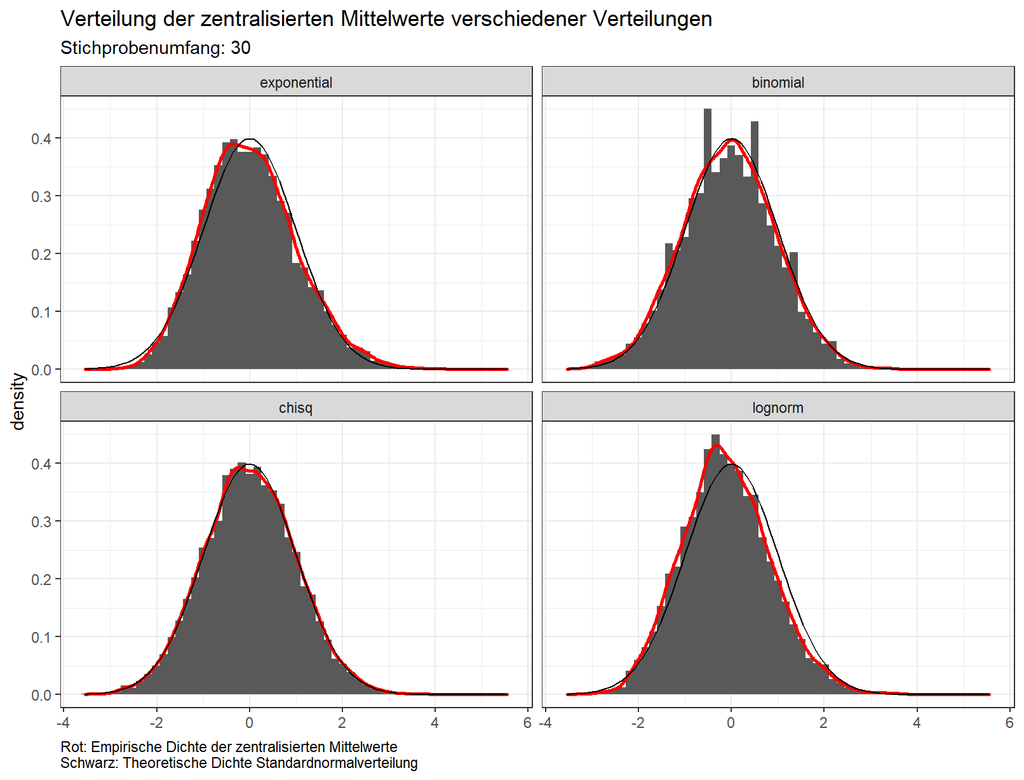

```r
# Histogramm mit Dichteschaetzer
data %>%
  ggplot(aes(centralised_means)) +
  geom_histogram(aes(y = ..density..), bins = 55) +
  geom_density(col = "red", size = 1) +
  stat_function(fun = "dnorm") +
  labs(title = "Verteilung der zentralisierten Mittelwerte verschiedener Verteilungen",
       subtitle = "Stichprobenumfang: 30",
       caption = "Rot: Empirische Dichte der zentralisierten Mittelwerte \nSchwarz: Theoretische Dichte Standardnormalverteilung") +
  theme(axis.title.x = element_blank(),
        plot.caption = element_text(hjust = 0)) +
  facet_wrap(~ distribution)
```

Ein weiterer Blick auf die empirischen Verteilungsfunktionen verglichen mit der theoretischen Verteilungsfunktion der Standardnormalverteilung bestätigt den Zentralen Grenzwertsatz mit den vorliegend verwendeten Veteilungen.

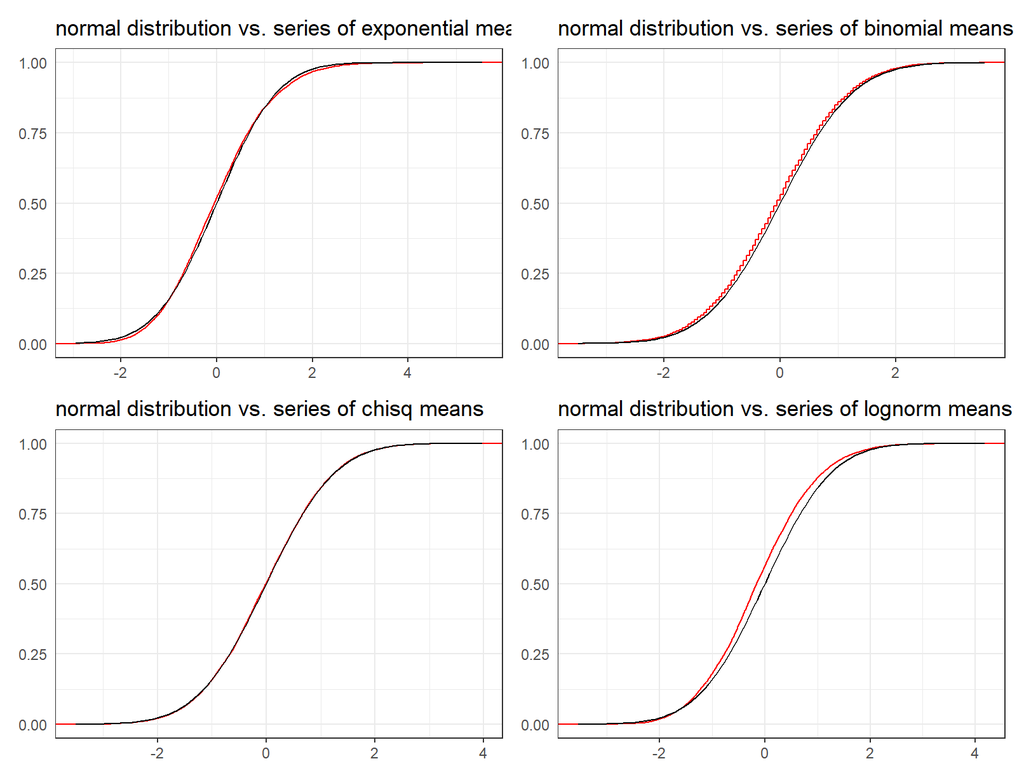

```r
# Empirische Verteilungsfunktion vs. theoretische Verteilungsfunktion
ecdf_graph = function(x,data){
  graphdata = data[distribution == x]
  pic <- ggplot(graphdata) +
    stat_ecdf(aes(centralised_means), geom = "step", col = "red") +
    stat_function(fun = pnorm) +
    labs(title = paste("normal distribution vs. series of",x,"means")) +
    theme(axis.title = element_blank(),
          axis.ticks.y = element_blank())
 return(pic)
}

graphics <- lapply(levels(data$distribution),ecdf_graph,data = data)
graphics[[1]] + graphics[[2]] + graphics[[3]] + graphics[[4]]
```

### Aufgabe 1.b)

Ermitteln Sie mit Hilfe der Simulation aus Aufgabe 1.a), ob die Faustregel, dass ab $n \approx 30$ das arithmetische Mittel näherungsweise normalverteilt ist, auch für eine sehr schiefe Verteilung (z.B. Lognormalverteilung mit Standardabweichung 2) wirklich sinnvolle Approximationen liefert. Wie groß sollten Sie n wählen?

Hierfür sehen wir uns einen Vektor der Mittelwerte einer Lognormal-Verteilung mit Standardabweichung 2 an. Die Funktion `get_sample_mean()` generiert jedoch für jede Mittelwertsverteilung eine neue Population, sodass eine leicht modifizierte Version zuvor implementiert werden muss (je Aufruf mit unterschiedlichen Stichprobengrößen würde eine neue Population gezogen, sodass für eine gegebene Population die Frage nach der “optimalen” Stichprobengröße nicht zuverlässig beantwortet werden könnte).

```r
get_sample_means2 = function(distribution,
                            sample_size_vector = seq.default(100,1500,100),
                            pop_size = 10000, sim = 10000,...){
  # Zufaelliger Seed fuer simulierte Werte
  set.seed(sample(1000000,1))
  # Verteilung abgreifen
  distr = match.fun(distribution)
  # Grundgesamtheit als Auspraegungen der gewaehlten Verteilung
  population = distr(pop_size, ...)
  # Vektor mit den Erwartungswerten je Samplegroesse erstellen
  vals = matrix(nrow = sim, ncol = length(sample_size_vector))
  for (i in seq_along(sample_size_vector)){
    vals[,i] <- replicate(sim,
                          mean(sample(population, sample_size_vector[i])))
  }
  result = list(dist_pop = population,
                mean_vals = vals)
  return(result)
}
```

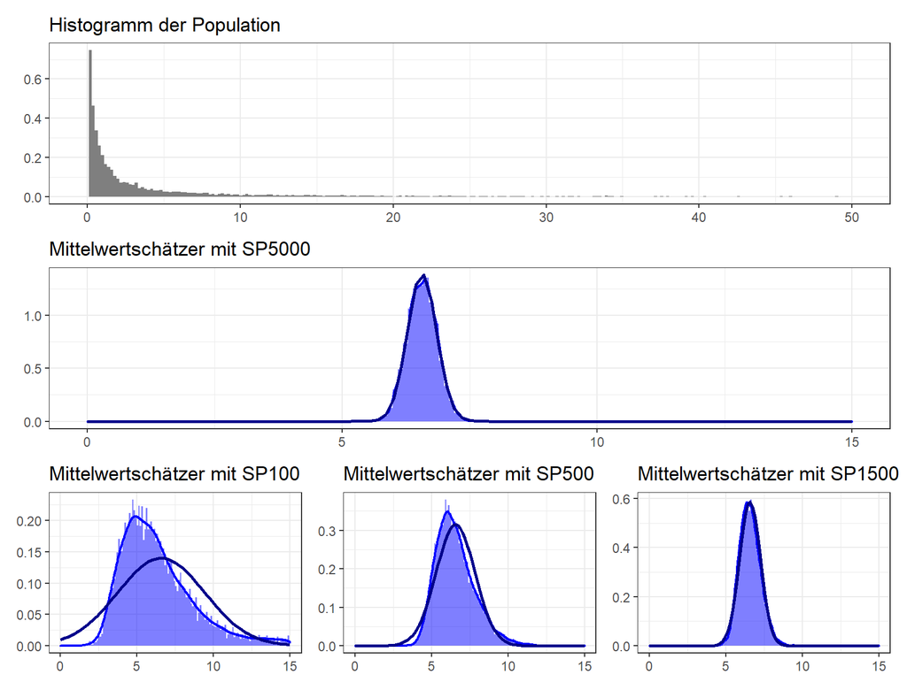

```r
# Matrix der Mittelwerte je Stichprobe
values = get_sample_means2("rlnorm",sdlog=2,sample_size_vector = c(100,500,1500,5000))
lognorm_sample_means = data.table(values$mean_vals)
setnames(lognorm_sample_means, paste0("SP",c(100,500,1500,5000)))
lognorm_sample_means = melt.data.table(lognorm_sample_means, measure.vars = 1:NCOL(lognorm_sample_means), variable.name =  "Stichprobenumfang", value.name = "Mittelwertschaetzer")
# Animation
hist_graphic = function(aes_col,data){
  mittelwert = mean(data[Stichprobenumfang == aes_col,Mittelwertschaetzer])
  standardabweichung = sd(data[Stichprobenumfang == aes_col,Mittelwertschaetzer])
  pic = ggplot(data[Stichprobenumfang == aes_col],
               aes(Mittelwertschaetzer)) +
    geom_histogram(aes(y = ..density..), fill = "blue", alpha = .5, bins = 150) +
    geom_density(col = "blue", size = .75) +
    stat_function(fun = dnorm, args =
                    list(mean = mittelwert,
                         sd = standardabweichung),
                  col = "darkblue", size = 1) +
    theme(axis.title = element_blank()) +
    labs(title = paste("Mittelwertschätzer mit",aes_col)) +
    xlim(0,15)
  return(pic)
}

graphics2_population <- ggplot(data = tibble(vals = values$dist_pop)) +
  geom_histogram(aes(vals,after_stat(density)),
                 fill = "grey50", bins = 250) +
  xlim(0,50) +
  labs(title = "Histogramm der Population") +
  theme(axis.title = element_blank())
graphics2 <- lapply(levels(lognorm_sample_means$Stichprobenumfang),
                    function(x) hist_graphic(aes_col = x, data = lognorm_sample_means))

graphics2_population / graphics2[[4]] / (graphics2[[1]] + graphics2[[2]] + graphics2[[3]])
```

### Aufgabe 1.c)

Untersuchen Sie obige Faustregel für symmetrische Verteilungen.

Bei symmetrischen Verteilungen kann es im Gegensatz zu den sehr schiefen Verteilungen nicht zu extremen Verzerrungen der Mittelwerte durch die extreme Varianz kommen. Entsprechend ist eine geringere Stichprobengröße ausreichend um eine hinreichende Annäherung an die Normalverteilung zu erreichen. Zusätzlich nähert sich die Mittelwertverteilung deutlicher schneller dem Populationsmittelwert an. In Konsequenz wird demnach eine deutlich geringere Stichprobengröße benötigt und für hinreichend große $n$ nähert sich die Verteilung der Dirac-Verteilung, ist also im Wesentlichen nur ein Ausschlag mit Varianz $\approx 0$ und Punktwert $\mathbb{E}(X)$. Anhand der Gleichverteilung soll dies kurz demonstriert werden.

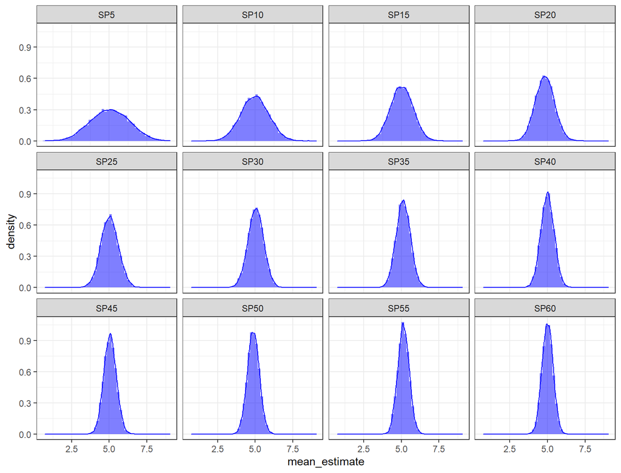

```r
sample_size_n = seq.default(5,60,5)
uniform_sample_means = data.table(do.call(
  cbind,
  lapply(sample_size_n,
         function(x) get_sample_mean(distribution = "runif",sample_size = x,
                         pop_size = 1000,sim = 10000,
                         min = 0, max = 10))))
setnames(uniform_sample_means, paste0("SP",sample_size_n))
uniform_sample_means <- melt.data.table(uniform_sample_means,measure.vars = 1:NCOL(uniform_sample_means), variable.name = "sample_size",value.name = "mean_estimate")
ggplot(uniform_sample_means, aes(mean_estimate)) +
  geom_histogram(aes(y = ..density..), bins = 50, alpha = .5, fill = "blue") +
  geom_density(col = "blue") +
  facet_wrap(~ sample_size)
```

Wie der Verlauf der Mittelwertschätzerverteilung zeigt, ist bereits für eine Stichprobengröße von 5 eine Glockenkurve erkennbar. Mit zunehmender Stichprobengröße verläuft der Anstieg um den theoretischen Mittelwert der Population zunehmend steiler (vgl. Dirac-Verteilung).

## Aufgabe 2

Bei der Berechnung herkömmlicher Konfidenzintervalle für den Parameter $\mu = \mathbb{E}(X)$ benötigt man als Voraussetzung die Normalverteilung des Merkmals $X \sim \mathscr{N}(\mu, \sigma^2)$. Ist diese Verteilungsannahme nicht haltbar oder prinzipiell nicht überprüfbar, kann für große Stichproben aufgrund des zentralen Grenzwertsatzes diese Annahme vernachlässigt werden. Für kleine Stichproben kann man ohne einer konkreten Verteilungsannahme mittels Bootstrapping ebenso Konfidenzintervalle ermitteln.

### Aufgabe 2.a)

Berechnen Sie für die Stichprobe `(10, 27, 30, 40, 46, 51, 52, 104, 146)` in R selbstständig das zweiseitige Konfidenzintervall basierend auf den Quantilen der Standardnormalverteilung.

Da die Intervallgrenzen nicht näher bezeichnet wurden, wird für diese sowieso die nachfolgenden Aufgaben das zweiseitige Konfidenzintervall zum Konfidenzniveau $\alpha = 5%$ beispielhaft berechnet.

```r
data_vec = c(10, 27, 30, 40, 46, 51, 52, 104, 146)
# 1. Stichprobenmittelwert
sp_mean = mean(data_vec)
# 2. z-Transformatione der Ober- und Untergrenze
z_up   =  qnorm(.975)
z_down = -qnorm(.975)
# 3. Stichprobenumfang
sp_n   =  length(data_vec)
# 4. Standardabweichung der Stichprobe
sp_sd  =  sd(data_vec)
# 5. Konfidenzintervalle berechnen
ki_down=  sp_mean + z_down * sp_sd/sqrt(sp_n)
ki_up  =  sp_mean + z_up * sp_sd/sqrt(sp_n)

c(ki_down,ki_up)
```

```
## [1] 28.47187 83.97257
```

### Aufgabe 2.b)

Berechnen Sie für die Stichprobe `(10, 27, 30, 40, 46, 51, 52, 104, 146)` in `R` selbstständig das zweiseitige Konfidenzintervall basierend auf den Quantilen der t-Verteilung.

```r
data_vec =  c(10, 27, 30, 40, 46, 51, 52, 104, 146)
# 1. Stichprobenmittelwert
sp_mean  =  mean(data_vec)
# 2. Freiheitsgrade und Stichprobenumfang
sp_df    =  length(data_vec) - 1
sp_n     =  length(data_vec)
# 3. z-Transformatione der Ober- und Untergrenze
z_up     =  qt(.975,df = sp_df)
z_down   = -qt(.975, df = sp_df)
# 4. Standardabweichung der Stichprobe
sp_sd    =  sd(data_vec)
# 5. Konfidenzintervalle berechnen
ki_down  =  sp_mean + z_down * sp_sd/sqrt(sp_n)
ki_up    =  sp_mean + z_up * sp_sd/sqrt(sp_n)

c(ki_down,ki_up)
```

```
## [1] 23.57242 88.87202
```

### Aufgabe 2.c)

Schreiben Sie eine eigene `R`-Funktion, die als Input einen Vektor der Stichprobe sowie das Konfidenzniveau $1 − \alpha$ erhält und als Output beide berechneten Konfidenzintervalle zurück gibt.

```r
calc_conf_int = function(vec,conf_niv){
  # t Student
  z_up_qt = qt(1 - (1 - conf_niv)/2, df = (length(vec) - 1))
  z_down_qt = -qt(1 - (1 - conf_niv)/2, df = (length(vec) - 1))
  result_qt = c(
    "lower" = mean(vec) + z_down_qt * sd(vec) / sqrt(length(vec)),
    "upper" = mean(vec) + z_up_qt * sd(vec) / sqrt(length(vec)))
  # Normal
  z_up_norm = qnorm(1 - (1 - conf_niv)/2)
  z_down_norm = -qnorm(1 - (1 - conf_niv)/2)

  result_norm = c(
    "lower" = mean(vec) + z_down_norm * sd(vec) / sqrt(length(vec)),
    "upper" = mean(vec) + z_up_norm * sd(vec) / sqrt(length(vec)))
  # Zusammenbinden
  result = rbind(result_qt, result_norm)
  rownames(result) <- c("tStudent","Normal")
  return(result)
}
calc_conf_int(data_vec,.95)
```

```
##             lower    upper
## tStudent 23.57242 88.87202
## Normal   28.47187 83.97257
```

### Aufgabe 2.d)

Ergänzen Sie in Ihrer Funktion die Berechnung eines Konfidenzintervalls mittels Bootstrapping. Erzeugen Sie hierfür mit der `R`-Funktion `sample()` aus Ihrer ursprünglichen Stichprobe vom Umfang $n$ insgesamt $B$ (beispielsweise $B = 10.000$) neue Stichproben vom Umfang $n$ mit Zurücklegen und ermitteln Sie die entsprechenden empirischen Quantile, so dass diese den Grenzen des zweiseitigen Konfidenzintervalls zum Niveau $1 − \alpha$ entsprechen.

```r
calc_conf_int_boot = function(vec,conf_niv,sim = 10000){
  # Abschnitt 1: Quantilsfunktionen
  # t Student
  z_up_qt = qt(1 - (1 - conf_niv)/2, df = (length(vec) - 1))
  z_down_qt = -qt(1 - (1 - conf_niv)/2, df = (length(vec) - 1))
  result_qt = c(
    "lower" = mean(vec) + z_down_qt * sd(vec) / sqrt(length(vec)),
    "upper" = mean(vec) + z_up_qt * sd(vec) / sqrt(length(vec)),
    "confidencelevel" = conf_niv,
    "sim_size" = NA)
  # Normal
  z_up_norm = qnorm(1 - (1 - conf_niv)/2)
  z_down_norm = -qnorm(1 - (1 - conf_niv)/2)

  result_norm = c(
    "lower" = mean(vec) + z_down_norm * sd(vec) / sqrt(length(vec)),
    "upper" = mean(vec) + z_up_norm * sd(vec) / sqrt(length(vec)),
    "confidencelevel" = conf_niv,
    "sim_size" = NA)
  # Abschnitt2: Bootstrapping-Verfahren
  bootstrap_sample = replicate(sim, mean(sample(vec,length(vec),TRUE)))
  # Herausfiltern der alpha/2 größten und kleinsten Werte
  # (Perzentil-KI als einfachste Form!)
  result_boot = c(
    "lower" = quantile(bootstrap_sample, 0 + (1 - conf_niv)/2),
    "upper" = quantile(bootstrap_sample, 1 - (1 - conf_niv)/2),
    "confidencelevel" = conf_niv,
    "sim_size" = sim)
  # Zusammenbinden
  result = rbind(result_qt, result_norm, result_boot)
  rownames(result) <- c("tStudent","Normal","Bootstrap")
  return(result)
}

table_data = do.call(rbind, lapply(c(1000,5000,10000), function(x) {
      do.call(rbind, lapply(c(.8,.9,.95), function(a) {
                 calc_conf_int_boot(data_vec, conf_niv = a, sim = x)
             }))
}))
table_data = as_tibble(table_data,rownames = "method") %>%
  group_by(method) %>%
  arrange(confidencelevel,.by_group = TRUE) %>%
  select(method,confidencelevel,sim_size,lower, upper)
table_data %>%
  knitr::kable()
```

| method | confidencelevel | sim_size | lower | upper |
| --- | --- | --- | --- | --- |
| Bootstrap | 0.80 | 1000 | 39.98889 | 74.90000 |
| Bootstrap | 0.80 | 5000 | 39.54444 | 74.11111 |
| Bootstrap | 0.80 | 10000 | 39.55556 | 74.33333 |
| Bootstrap | 0.90 | 1000 | 36.43889 | 79.34444 |
| Bootstrap | 0.90 | 5000 | 35.55556 | 79.67222 |
| Bootstrap | 0.90 | 10000 | 35.88889 | 79.77778 |
| Bootstrap | 0.95 | 1000 | 33.77500 | 82.55556 |
| Bootstrap | 0.95 | 5000 | 33.33056 | 85.22222 |
| Bootstrap | 0.95 | 10000 | 33.44444 | 84.77778 |
| Normal | 0.80 | NA | 38.07724 | 74.36720 |
| Normal | 0.80 | NA | 38.07724 | 74.36720 |
| Normal | 0.80 | NA | 38.07724 | 74.36720 |
| Normal | 0.90 | NA | 32.93339 | 79.51105 |
| Normal | 0.90 | NA | 32.93339 | 79.51105 |
| Normal | 0.90 | NA | 32.93339 | 79.51105 |
| Normal | 0.95 | NA | 28.47187 | 83.97257 |
| Normal | 0.95 | NA | 28.47187 | 83.97257 |
| Normal | 0.95 | NA | 28.47187 | 83.97257 |
| tStudent | 0.80 | NA | 36.44527 | 75.99918 |
| tStudent | 0.80 | NA | 36.44527 | 75.99918 |
| tStudent | 0.80 | NA | 36.44527 | 75.99918 |
| tStudent | 0.90 | NA | 29.89362 | 82.55083 |
| tStudent | 0.90 | NA | 29.89362 | 82.55083 |
| tStudent | 0.90 | NA | 29.89362 | 82.55083 |
| tStudent | 0.95 | NA | 23.57242 | 88.87202 |
| tStudent | 0.95 | NA | 23.57242 | 88.87202 |
| tStudent | 0.95 | NA | 23.57242 | 88.87202 |

### Aufgabe 2.e)

Machen Sie sich mit den R-Funktionen `boot()` und `boot.ci()` des R-Pakets `boot` vertraut und berechnen Sie mit deren Hilfe Konfidenzintervalle mittels Bootstrapping.

```r
get_mean = function(x,d){
  return(mean(x[d]))
}
test = boot(data_vec,
     statistic = get_mean,
     R = 10000)
boot.ci(test, type = "perc")
```

```
## BOOTSTRAP CONFIDENCE INTERVAL CALCULATIONS
## Based on 10000 bootstrap replicates
##
## CALL :
## boot.ci(boot.out = test, type = "perc")
##
## Intervals :
## Level     Percentile
## 95%   (33.11, 84.11 )
## Calculations and Intervals on Original Scale
```